# Covid19 vaccine study Fall2021

Marcia Alarcon

2021-12-04

# Introduction

A new preventative vaccine (covid91) is under test in clinical trials. Given the nature of this vaccine it is suspected that the drug may exhibit different effectiveness across the variety of subpopulations tracked. Consider population subgroups consisting of Males, Females, just the drug users, and just those in the LGBTQ community. Write a complete report that separately considers this drug for each subgroup and your recommendations as to whether people in the subgroup should take the vaccine. Part of the information you need to compute is the so-called effectiveness of the drug for each subgroup of people. Include a 95% confidence interval of the effectiveness for each different subgroup. Structure your report in four sections each devoted to one of the four subgroups, use null and alternative hypothesis statements and correct statistical verbage when referencing p-values in conclusions.

# Males

```r
malesDataSet = filter(TheData, sex == "guy")
```

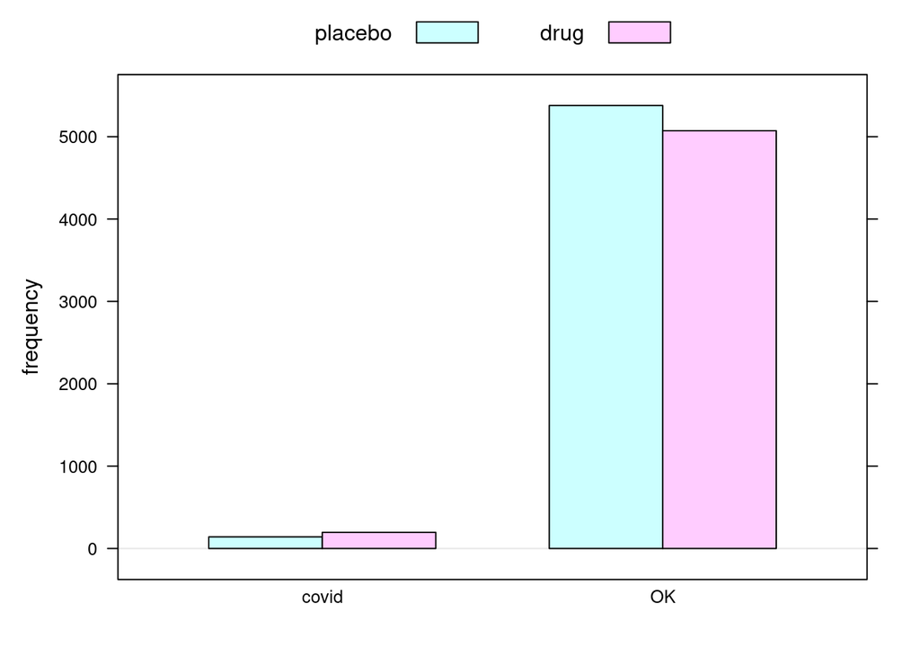

```r
barchartGC(~infected + treatment,data=malesDataSet)
```

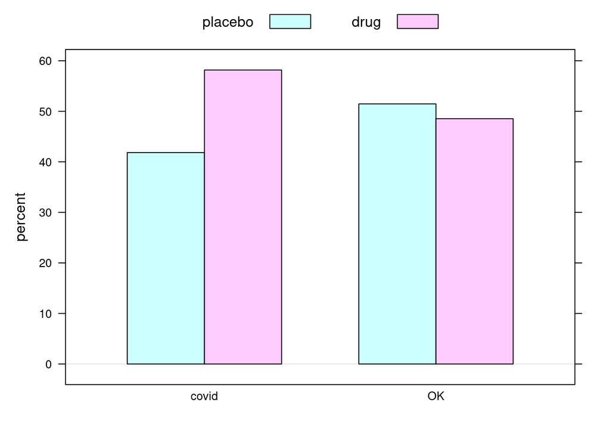

```r
barchartGC(~infected + treatment,data=malesDataSet, type="percent")
```

The data shows that majority of the population of males were not infected, however the guys who received the treatment actually were more likely to contract Covid than those who received the placebo.

### Numerical Summaries

```r
tableMales <- xtabs(~infected + treatment, data=malesDataSet)
rowPerc(tableMales)
```

```
##         treatment
## infected placebo   drug  Total
##    covid   41.84  58.16 100.00
##    OK      51.46  48.54 100.00
```

```r
colPerc(tableMales)
```

```
##         treatment
## infected placebo   drug
##    covid    2.55   3.72
##    OK      97.45  96.28
##    Total  100.00 100.00
```

## Inferential

```r
chisq.test(tableMales)
```

```
##
##  Pearson's Chi-squared test with Yates' continuity correction
##
## data:  tableMales
## X-squared = 11.721, df = 1, p-value = 0.0006181
```

```r
chisqtestGC(tableMales)
```

```
## Pearson's Chi-squared test with Yates' continuity correction
##
## Observed Counts:
##         treatment
## infected placebo drug
##    covid     141  196
##    OK       5378 5072
##
## Counts Expected by Null:
##         treatment
## infected placebo    drug
##    covid  172.42  164.58
##    OK    5346.58 5103.42
##
## Contributions to the chi-square statistic:
##         treatment
## infected placebo drug
##    covid    5.73 6.00
##    OK       0.18 0.19
##
##
## Chi-Square Statistic = 11.7206
## Degrees of Freedom of the table = 1
## P-Value = 6e-04
```

```r
fisher.test(tableMales) -> fisherResult
print(fisherResult)
```

```
##
##  Fisher's Exact Test for Count Data
##
## data:  tableMales
## p-value = 0.0005801
## alternative hypothesis: true odds ratio is not equal to 1
## 95 percent confidence interval:
##  0.5406079 0.8497815
## sample estimates:
## odds ratio
##  0.6784848
```

The Pearson Chi Square test the p-value is 0.0006181

In the Fisher test the p-value is 0.0005801

Get the effectiveness for the odds ratio 0.678

```r
effectiveness = fisherResult$estimate/(fisherResult$estimate+1)*100
```

The drug effectiveness for males is 40.4224576%

# Females

```r
femalesDataSet = filter(TheData, sex == "gal")
```

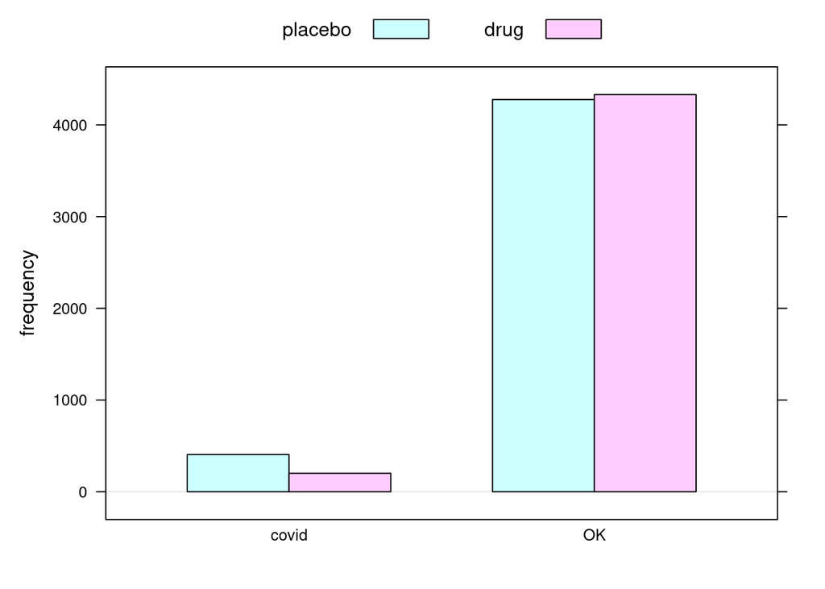

```r
barchartGC(~infected + treatment,data=femalesDataSet)
```

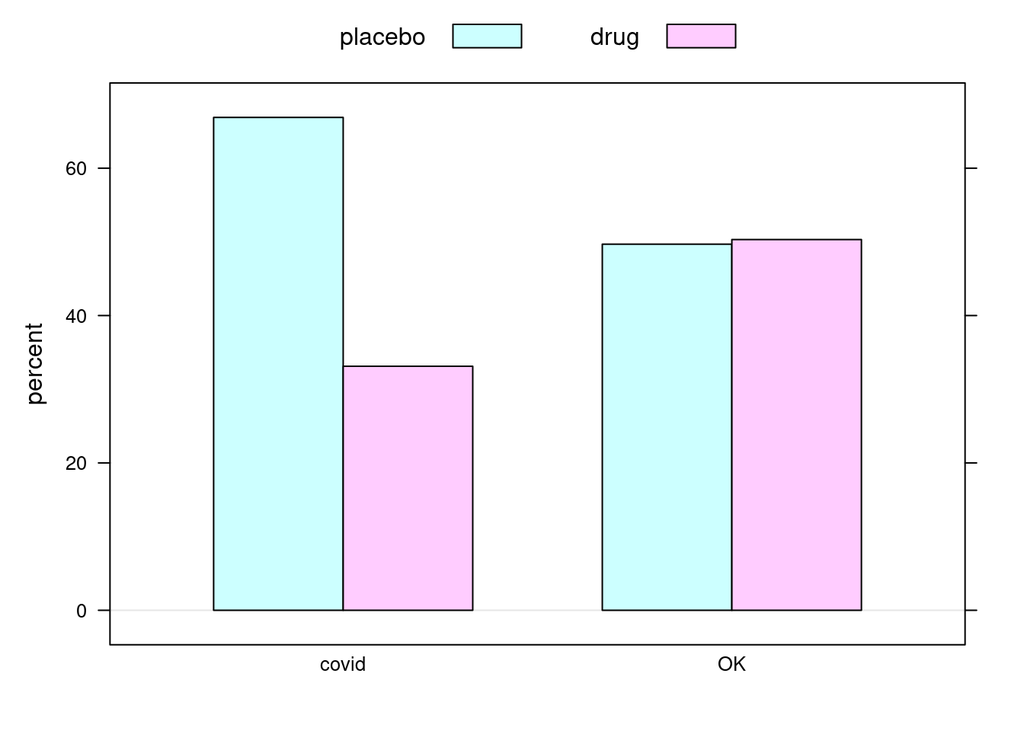

```r
barchartGC(~infected + treatment,data=femalesDataSet, type="percent")
```

The data shows that majority of the population of females were not infected, however the females who received the treatment actually were less likely to contract Covid than those who received the placebo.

### Numerical Summaries

```r
tableFemales <- xtabs(~infected + treatment, data=femalesDataSet)
rowPerc(tableFemales)
```

```
##         treatment
## infected placebo   drug  Total
##    covid   66.89  33.11 100.00
##    OK      49.69  50.31 100.00
```

```r
colPerc(tableFemales)
```

```
##         treatment
## infected placebo   drug
##    covid    8.67   4.44
##    OK      91.33  95.56
##    Total  100.00 100.00
```

## Inferential

```r
chisq.test(tableFemales)
```

```
##
##  Pearson's Chi-squared test with Yates' continuity correction
##
## data:  tableFemales
## X-squared = 66.43, df = 1, p-value = 3.626e-16
```

```r
chisqtestGC(tableFemales)
```

```
## Pearson's Chi-squared test with Yates' continuity correction
##
## Observed Counts:
##         treatment
## infected placebo drug
##    covid     406  201
##    OK       4276 4330
##
## Counts Expected by Null:
##         treatment
## infected placebo    drug
##    covid  308.47  298.53
##    OK    4373.53 4232.47
##
## Contributions to the chi-square statistic:
##         treatment
## infected placebo  drug
##    covid   30.83 31.86
##    OK       2.17  2.25
##
##
## Chi-Square Statistic = 66.4295
## Degrees of Freedom of the table = 1
## P-Value = 0
```

```r
fisher.test(tableFemales) -> fisherResult
print(fisherResult)
```

```
##
##  Fisher's Exact Test for Count Data
##
## data:  tableFemales
## p-value < 2.2e-16
## alternative hypothesis: true odds ratio is not equal to 1
## 95 percent confidence interval:
##  1.713470 2.447107
## sample estimates:
## odds ratio
##   2.045239
```

In the Fisher test the p-value is 0.00000000000000022

Get the effectiveness for the odds ratio 2.045

```r
effectiveness = fisherResult$estimate/(fisherResult$estimate+1)*100
```

The drug effectiveness for females is 67.1618599%

# Drug Users

```r
DrugUserYesDataSet = filter(TheData, DrugUser == "yes")
```

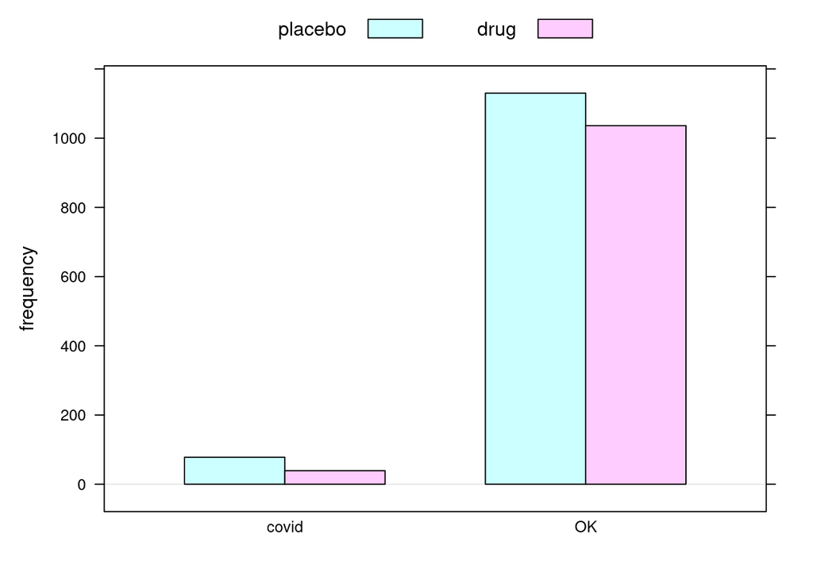

```r
barchartGC(~infected + treatment,data=DrugUserYesDataSet)
```

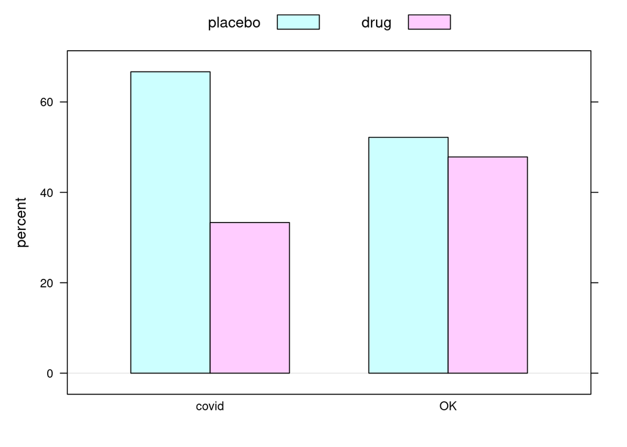

```r
barchartGC(~infected + treatment,data=DrugUserYesDataSet, type="percent")
```

The data shows that majority of the population of drug users were not infected, however the drug users who received the treatment actually were less likely to contract Covid than those who received the placebo.

### Numerical Summaries

```r
tableDrugUserYes <- xtabs(~infected + treatment, data=DrugUserYesDataSet)
rowPerc(tableDrugUserYes)
```

```
##         treatment
## infected placebo   drug  Total
##    covid   66.67  33.33 100.00
##    OK      52.17  47.83 100.00
```

```r
colPerc(tableDrugUserYes)
```

```
##         treatment
## infected placebo   drug
##    covid    6.46   3.63
##    OK      93.54  96.37
##    Total  100.00 100.00
```

## Inferential

```r
chisq.test(tableDrugUserYes)
```

```
##
##  Pearson's Chi-squared test with Yates' continuity correction
##
## data:  tableDrugUserYes
## X-squared = 8.7902, df = 1, p-value = 0.003028
```

```r
chisqtestGC(tableDrugUserYes)
```

```
## Pearson's Chi-squared test with Yates' continuity correction
##
## Observed Counts:
##         treatment
## infected placebo drug
##    covid      78   39
##    OK       1130 1036
##
## Counts Expected by Null:
##         treatment
## infected placebo    drug
##    covid   61.91   55.09
##    OK    1146.09 1019.91
##
## Contributions to the chi-square statistic:
##         treatment
## infected placebo drug
##    covid    4.18 4.70
##    OK       0.23 0.25
##
##
## Chi-Square Statistic = 8.7902
## Degrees of Freedom of the table = 1
## P-Value = 0.003
```

```r
fisher.test(tableDrugUserYes) -> fisherResult
print(fisherResult)
```

```
##
##  Fisher's Exact Test for Count Data
##
## data:  tableDrugUserYes
## p-value = 0.002273
## alternative hypothesis: true odds ratio is not equal to 1
## 95 percent confidence interval:
##  1.220336 2.792730
## sample estimates:
## odds ratio
##   1.833149
```

The Pearson Chi Square test the p-value is 0.003028

In the Fisher test the p-value is 0.002273

Get the effectiveness for the odds ratio 1.833

```r
effectiveness = fisherResult$estimate/(fisherResult$estimate+1)*100
```

The drug effectiveness for drug users is 64.7035885%

# LGBTQ

```r
LGBTQDataSet = filter(TheData, LGBTQ == "gay")
```

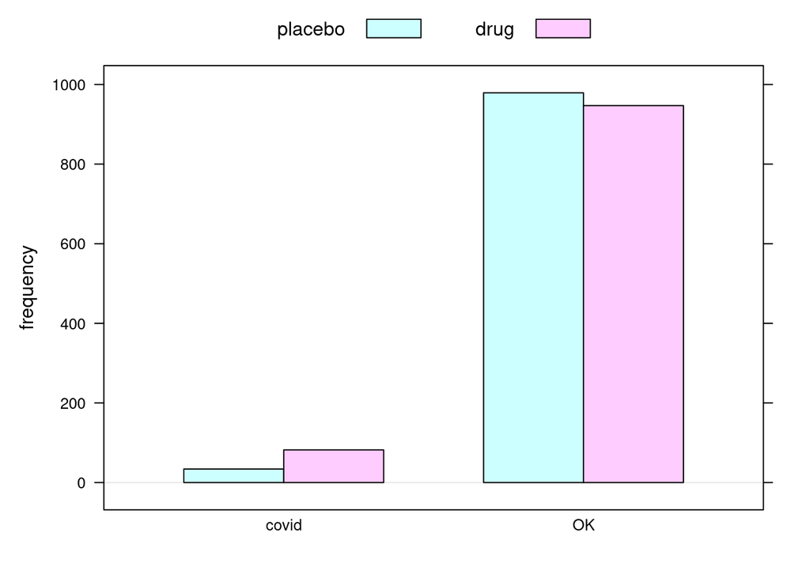

```r
barchartGC(~infected + treatment,data=LGBTQDataSet)
```

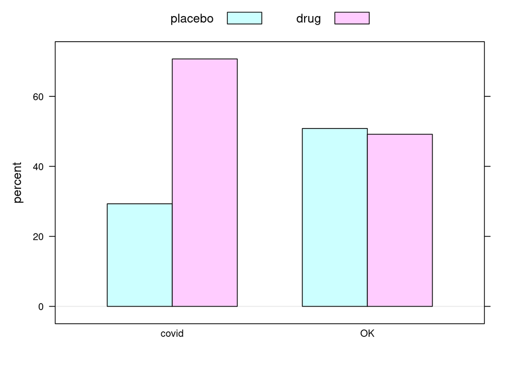

```r
barchartGC(~infected + treatment,data=LGBTQDataSet, type="percent")
```

The data shows that majority of the population of LGBTQ were not infected, however the LGBTQ members who received the treatment actually were more likely to contract Covid than those who received the placebo.

### Numerical Summaries

```r
tableLGBTQ <- xtabs(~infected + treatment, data=LGBTQDataSet)
rowPerc(tableLGBTQ)
```

```
##         treatment
## infected placebo   drug  Total
##    covid   29.31  70.69 100.00
##    OK      50.83  49.17 100.00
```

```r
colPerc(tableLGBTQ)
```

```
##         treatment
## infected placebo   drug
##    covid    3.36   7.97
##    OK      96.64  92.03
##    Total  100.00 100.00
```

## Inferential

```r
chisq.test(tableLGBTQ)
```

```
##
##  Pearson's Chi-squared test with Yates' continuity correction
##
## data:  tableLGBTQ
## X-squared = 19.418, df = 1, p-value = 1.05e-05
```

```r
chisqtestGC(tableLGBTQ)
```

```
## Pearson's Chi-squared test with Yates' continuity correction
##
## Observed Counts:
##         treatment
## infected placebo drug
##    covid      34   82
##    OK        979  947
##
## Counts Expected by Null:
##         treatment
## infected placebo   drug
##    covid   57.55  58.45
##    OK     955.45 970.55
##
## Contributions to the chi-square statistic:
##         treatment
## infected placebo drug
##    covid    9.63 9.48
##    OK       0.58 0.57
##
##
## Chi-Square Statistic = 19.4179
## Degrees of Freedom of the table = 1
## P-Value = 0
```

```r
fisher.test(tableLGBTQ) -> fisherResult
print(fisherResult)
```

```
##
##  Fisher's Exact Test for Count Data
##
## data:  tableLGBTQ
## p-value = 5.741e-06
## alternative hypothesis: true odds ratio is not equal to 1
## 95 percent confidence interval:
##  0.2580733 0.6121070
## sample estimates:
## odds ratio
##  0.4012509
```

The Pearson Chi Square test the p-value is 0.0000105

In the Fisher test the p-value is 0.000005741

Get the effectiveness for the odds ratio 0.401

```r
effectiveness = fisherResult$estimate/(fisherResult$estimate+1)*100
```

The drug effectiveness for LBGTQ is 28.635192%

# Conclusions and recommendations

In conclusion the men who received the drug were more likely to get Covid than the ones who got the placebo. Females who received the drug were less likely to get Covid than those who got the placebo. Just like the females the drug users had similar reactions. In the LGBTQ community show that those who received the drug were more likely to get covid than the ones who go the placebo just like the mens results. Recommendation regardless of gender, secual orientation, and if one uses drugs or not one need to take the same precautions because whether or not one recieves treatment there is still possibility of contracting covid.